# A7: Kickstarter

Author

Matthew Reiling

Published

February 25, 2026

```r
library(dplyr)
library(ggplot2)
library(lubridate)
```

### Loading data

```r
setwd("~/Documents/INFO 201")
kickstarter_df <- read.csv("ks-projects-201801.csv")
glimpse(kickstarter_df)
```

```
Rows: 378,661
Columns: 15
$ ID               <int> 1000002330, 1000003930, 1000004038, 1000007540, 10000…
$ name             <chr> "The Songs of Adelaide & Abullah", "Greeting From Ear…
$ category         <chr> "Poetry", "Narrative Film", "Narrative Film", "Music"…
$ main_category    <chr> "Publishing", "Film & Video", "Film & Video", "Music"…
$ currency         <chr> "GBP", "USD", "USD", "USD", "USD", "USD", "USD", "USD…
$ deadline         <chr> "2015-10-09", "2017-11-01", "2013-02-26", "2012-04-16…
$ goal             <dbl> 1000, 30000, 45000, 5000, 19500, 50000, 1000, 25000, …
$ launched         <chr> "2015-08-11 12:12:28", "2017-09-02 04:43:57", "2013-0…
$ pledged          <dbl> 0.00, 2421.00, 220.00, 1.00, 1283.00, 52375.00, 1205.…
$ state            <chr> "failed", "failed", "failed", "failed", "canceled", "…
$ backers          <int> 0, 15, 3, 1, 14, 224, 16, 40, 58, 43, 0, 100, 0, 0, 7…
$ country          <chr> "GB", "US", "US", "US", "US", "US", "US", "US", "US",…
$ usd.pledged      <dbl> 0.00, 100.00, 220.00, 1.00, 1283.00, 52375.00, 1205.0…
$ usd_pledged_real <dbl> 0.00, 2421.00, 220.00, 1.00, 1283.00, 52375.00, 1205.…
$ usd_goal_real    <dbl> 1533.95, 30000.00, 45000.00, 5000.00, 19500.00, 50000…
```

### Processing data

```r
kickstarter_df <- kickstarter_df |>
  mutate(deadline_date = as.Date(deadline),
         launched_date = as.Date(launched))
kickstarter_df <- kickstarter_df |>
  mutate(deadline_year = year(deadline_date),
         launched_year = year(launched_date))
glimpse(kickstarter_df)
```

```
Rows: 378,661
Columns: 19
$ ID               <int> 1000002330, 1000003930, 1000004038, 1000007540, 10000…
$ name             <chr> "The Songs of Adelaide & Abullah", "Greeting From Ear…
$ category         <chr> "Poetry", "Narrative Film", "Narrative Film", "Music"…
$ main_category    <chr> "Publishing", "Film & Video", "Film & Video", "Music"…
$ currency         <chr> "GBP", "USD", "USD", "USD", "USD", "USD", "USD", "USD…
$ deadline         <chr> "2015-10-09", "2017-11-01", "2013-02-26", "2012-04-16…
$ goal             <dbl> 1000, 30000, 45000, 5000, 19500, 50000, 1000, 25000, …
$ launched         <chr> "2015-08-11 12:12:28", "2017-09-02 04:43:57", "2013-0…
$ pledged          <dbl> 0.00, 2421.00, 220.00, 1.00, 1283.00, 52375.00, 1205.…
$ state            <chr> "failed", "failed", "failed", "failed", "canceled", "…
$ backers          <int> 0, 15, 3, 1, 14, 224, 16, 40, 58, 43, 0, 100, 0, 0, 7…
$ country          <chr> "GB", "US", "US", "US", "US", "US", "US", "US", "US",…
$ usd.pledged      <dbl> 0.00, 100.00, 220.00, 1.00, 1283.00, 52375.00, 1205.0…
$ usd_pledged_real <dbl> 0.00, 2421.00, 220.00, 1.00, 1283.00, 52375.00, 1205.…
$ usd_goal_real    <dbl> 1533.95, 30000.00, 45000.00, 5000.00, 19500.00, 50000…
$ deadline_date    <date> 2015-10-09, 2017-11-01, 2013-02-26, 2012-04-16, 2015…
$ launched_date    <date> 2015-08-11, 2017-09-02, 2013-01-12, 2012-03-17, 2015…
$ deadline_year    <dbl> 2015, 2017, 2013, 2012, 2015, 2016, 2014, 2016, 2014,…
$ launched_year    <dbl> 2015, 2017, 2013, 2012, 2015, 2016, 2014, 2016, 2014,…
```

### Initial calculations

```r
num_projects <- kickstarter_df |> nrow()
num_successful <- kickstarter_df |> filter(state == "successful") |> nrow()
num_failed <- kickstarter_df |> filter(state == "failed") |> nrow()
perc_failed <- round(num_failed / num_projects, 2) * 100
```

Out of a total of 378661 projects on Kickstarter, 133956 projects were considered successful and 197719 projects were considered failed. This leaves us with 52% of total projects considered failed.

### Biggest non-success

```r
biggest_non_success <- kickstarter_df |>
  filter(state != "successful") |>
  filter(usd_pledged_real == max(usd_pledged_real))
```

The biggest “non-success” on Kickstarter is The Skarp Laser Razor: 21st Century Shaving. It gained more than 4 million dollars worth of crowdfunding support in less than three weeks of being on Kickstarter. However, Kickstarter suspended the campaign after they alleged that Skarp had acted in violation of their rules.

### Project state

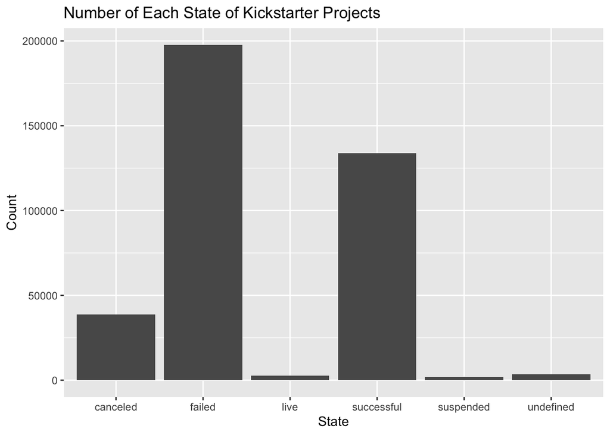

```r
state_count_df <- kickstarter_df |> group_by(state) |> summarize(count = n())
ggplot(state_count_df) +
  geom_col(aes(state, count)) +
  labs(title = "Number of Each State of Kickstarter Projects",
       x = "State",
       y = "Count")
```

The ‘failed’ state has by far the highest count compared to any other in this dataset.

### Yearly summary

```r
yearly_summary_df <- kickstarter_df |>
  group_by(year = deadline_year) |>
  summarize(count = n(),
            successful_count = sum(state == "successful"),
            most_pledged = max(pledged))
yearly_summary_df <- yearly_summary_df |>
  mutate(perc_successful = round(successful_count / count, 2) * 100) |>
  select(!successful_count)
print(yearly_summary_df)
```

```
# A tibble: 10 × 4
    year count most_pledged perc_successful
   <dbl> <int>        <dbl>           <dbl>
 1  2009   902       84614.              43
 2  2010  9098      942578.              44
 3  2011 25107      830828.              47
 4  2012 41560    10266846.              43
 5  2013 44178     5702153.              43
 6  2014 66231    13285226.              32
 7  2015 77498    20338986.              27
 8  2016 58074    12779843.              32
 9  2017 52741    12393140.              37
10  2018  3272     1104279                3
```

When choosing the year to use in grouping, I went with the deadline_year variable because launched_year had some projects that were launched in 1970 which I thought would be unreasonable to have a section for 1970 in this dataset. Percent success I compared the number of successful projects to all other project states for two reasons: it was easier and in my personal opinion I believed it would be more accurate to compare it to all other states rather than just successful and failed projects. For the summary of the pledges, I chose to find the max amount pledged each year simply because it sounded interesting to me.

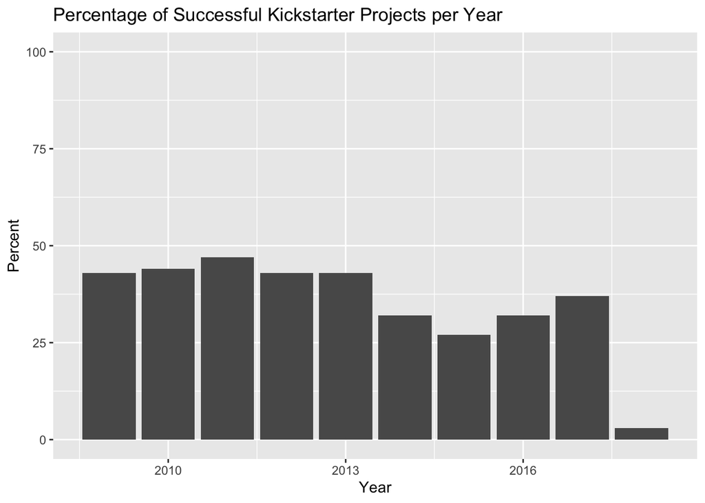

```r
ggplot(yearly_summary_df) + geom_col(aes(year, perc_successful)) +
  labs(title = "Percentage of Successful Kickstarter Projects per Year",
       x = "Year",
       y = "Percent") +
  ylim(0, 100)
```

Between the years 2009-2013, the percentage of successful project seems to remain mostly the same, sitting around 45% success rate. After this period, we can see a drop off of success percent and a strikingly low success percent in 2018.

### Unusual data values

Looking at the above graph, I want to go more into why 2018 appears to be such a significant outlier in our dataset. I believe that this could be due to data having stopped being collected in 2017 and while it included datasets that had been launched in 2017, their deadlines were in 2018 so the vast majority of them simply did not have time to reach their pledge goal before data had stopped being observed. A follow-up question I have regarding this is would it not be more accurate to look only at data sets up until the end of 2017 but continue to collect data on all of the projects until they had all reached their deadline date?